# **Problem Statement**

#### **Business Context**

Understanding customer personality and behavior is pivotal for businesses to enhance customer satisfaction and increase revenue. Segmentation based on a customer's personality, demographics, and purchasing behavior allows companies to create tailored marketing campaigns, improve customer retention, and optimize product offerings.

A leading retail company with a rapidly growing customer base seeks to gain deeper insights into their customers' profiles. The company recognizes that understanding customer personalities, lifestyles, and purchasing habits can unlock significant opportunities for personalizing marketing strategies and creating loyalty programs. These insights can help address critical business challenges, such as improving the effectiveness of marketing campaigns, identifying high-value customer groups, and fostering long-term relationships with customers.

With the competition intensifying in the retail space, moving away from generic strategies to more targeted and personalized approaches is essential for sustaining a competitive edge.

#### **Objective**

In an effort to optimize marketing efficiency and enhance customer experience, the company has embarked on a mission to identify distinct customer segments. By understanding the characteristics, preferences, and behaviors of each group, the company aims to:

1. Develop personalized marketing campaigns to increase conversion rates.
2. Create effective retention strategies for high-value customers.
3. Optimize resource allocation, such as inventory management, pricing strategies, and store layouts.

As a data scientist tasked with this project, your responsibility is to analyze the given customer data, apply machine learning techniques to segment the customer base, and provide actionable insights into the characteristics of each segment.

#### **Data Dictionary**

The dataset includes historical data on customer demographics, personality traits, and purchasing behaviors. Key attributes are:

1. **Customer Information**
   - **ID:** Unique identifier for each customer.
   - **Year_Birth:** Customer's year of birth.
   - **Education:** Education level of the customer.
   - **Marital_Status:** Marital status of the customer.
   - **Income:** Yearly household income (in dollars).
   - **Kidhome:** Number of children in the household.
   - **Teenhome:** Number of teenagers in the household.
   - **Dt_Customer:** Date when the customer enrolled with the company.
   - **Recency:** Number of days since the customer’s last purchase.
   - **Complain:** Whether the customer complained in the last 2 years (1 for yes, 0 for no).
2. **Spending Information (Last 2 Years)**
   - **MntWines:** Amount spent on wine.
   - **MntFruits:** Amount spent on fruits.
   - **MntMeatProducts:** Amount spent on meat.
   - **MntFishProducts:** Amount spent on fish.
   - **MntSweetProducts:** Amount spent on sweets.
   - **MntGoldProds:** Amount spent on gold products.
3. **Purchase and Campaign Interaction**
   - **NumDealsPurchases:** Number of purchases made using a discount.
   - **AcceptedCmp1:** Response to the 1st campaign (1 for yes, 0 for no).
   - **AcceptedCmp2:** Response to the 2nd campaign (1 for yes, 0 for no).
   - **AcceptedCmp3:** Response to the 3rd campaign (1 for yes, 0 for no).
   - **AcceptedCmp4:** Response to the 4th campaign (1 for yes, 0 for no).
   - **AcceptedCmp5:** Response to the 5th campaign (1 for yes, 0 for no).
   - **Response:** Response to the last campaign (1 for yes, 0 for no).
4. **Shopping Behavior**
   - **NumWebPurchases:** Number of purchases made through the company’s website.
   - **NumCatalogPurchases:** Number of purchases made using catalogs.
   - **NumStorePurchases:** Number of purchases made directly in stores.
   - **NumWebVisitsMonth:** Number of visits to the company’s website in the last month.

# **Let's start coding!**

## **Importing necessary libraries**

```python
# Libraries to help with reading and manipulating data
import pandas as pd
import numpy as np

# libaries to help with data visualization
import matplotlib.pyplot as plt
import seaborn as sns

# Removes the limit for the number of displayed columns
pd.set_option("display.max_columns", None)
# Sets the limit for the number of displayed rows
pd.set_option("display.max_rows", 200)

# to scale the data using z-score
from sklearn.preprocessing import StandardScaler

# to compute distances
from scipy.spatial.distance import cdist, pdist

# to perform k-means clustering and compute silhouette scores
from sklearn.cluster import KMeans
from sklearn.metrics import silhouette_score

# to visualize the elbow curve and silhouette scores
from yellowbrick.cluster import KElbowVisualizer, SilhouetteVisualizer

# to suppress warnings
import warnings

import time

warnings.filterwarnings("ignore")
```

## **Loading the data**

```python
# uncomment and run the following line if using Google Colab
# from google.colab import drive
# drive.mount('/content/drive')
```

```python
# loading data into a pandas dataframe
data = pd.read_csv("/content/sample_data/Customer_Personality_Segmentation.csv", sep="\t")
```

## **Data Overview**

#### **Question 1**: What are the data types of all the columns?

```python
# Write your code here.
data.info()
```

```
<class 'pandas.core.frame.DataFrame'>
RangeIndex: 2240 entries, 0 to 2239
Data columns (total 29 columns):
 #   Column               Non-Null Count  Dtype
---  ------               --------------  -----
 0   ID                   2240 non-null   int64
 1   Year_Birth           2240 non-null   int64
 2   Education            2240 non-null   object
 3   Marital_Status       2240 non-null   object
 4   Income               2216 non-null   float64
 5   Kidhome              2240 non-null   int64
 6   Teenhome             2240 non-null   int64
 7   Dt_Customer          2240 non-null   object
 8   Recency              2240 non-null   int64
 9   MntWines             2240 non-null   int64
```

[output cut: 21 more lines]

##### **Observations:**

- int64: 25 columns (mostly numerical data like counts, amounts, and binary indicators)
- float64: 1 column (Income - likely contains decimal values)
- object: 3 columns (categorical/text data like Education level, Marital Status, and Customer date)

#### **Question 2:** Check the statistical summary of the data. What is the average household income?

```python
data.describe()
```

|  | ID | Year_Birth | Income | Kidhome | Teenhome | Recency | MntWines | MntFruits | MntMeatProducts | MntFishProducts | MntSweetProducts | MntGoldProds | NumDealsPurchases | NumWebPurchases | NumCatalogPurchases | NumStorePurchases | NumWebVisitsMonth | AcceptedCmp3 | AcceptedCmp4 | AcceptedCmp5 | AcceptedCmp1 | AcceptedCmp2 | Complain | Z_CostContact | Z_Revenue | Response |
| --- | --- | --- | --- | --- | --- | --- | --- | --- | --- | --- | --- | --- | --- | --- | --- | --- | --- | --- | --- | --- | --- | --- | --- | --- | --- | --- |
| count | 2240.000000 | 2240.000000 | 2216.000000 | 2240.000000 | 2240.000000 | 2240.000000 | 2240.000000 | 2240.000000 | 2240.000000 | 2240.000000 | 2240.000000 | 2240.000000 | 2240.000000 | 2240.000000 | 2240.000000 | 2240.000000 | 2240.000000 | 2240.000000 | 2240.000000 | 2240.000000 | 2240.000000 | 2240.000000 | 2240.000000 | 2240.0 | 2240.0 | 2240.000000 |
| mean | 5592.159821 | 1968.805804 | 52247.251354 | 0.444196 | 0.506250 | 49.109375 | 303.935714 | 26.302232 | 166.950000 | 37.525446 | 27.062946 | 44.021875 | 2.325000 | 4.084821 | 2.662054 | 5.790179 | 5.316518 | 0.072768 | 0.074554 | 0.072768 | 0.064286 | 0.013393 | 0.009375 | 3.0 | 11.0 | 0.149107 |
| std | 3246.662198 | 11.984069 | 25173.076661 | 0.538398 | 0.544538 | 28.962453 | 336.597393 | 39.773434 | 225.715373 | 54.628979 | 41.280498 | 52.167439 | 1.932238 | 2.778714 | 2.923101 | 3.250958 | 2.426645 | 0.259813 | 0.262728 | 0.259813 | 0.245316 | 0.114976 | 0.096391 | 0.0 | 0.0 | 0.356274 |
| min | 0.000000 | 1893.000000 | 1730.000000 | 0.000000 | 0.000000 | 0.000000 | 0.000000 | 0.000000 | 0.000000 | 0.000000 | 0.000000 | 0.000000 | 0.000000 | 0.000000 | 0.000000 | 0.000000 | 0.000000 | 0.000000 | 0.000000 | 0.000000 | 0.000000 | 0.000000 | 0.000000 | 3.0 | 11.0 | 0.000000 |
| 25% | 2828.250000 | 1959.000000 | 35303.000000 | 0.000000 | 0.000000 | 24.000000 | 23.750000 | 1.000000 | 16.000000 | 3.000000 | 1.000000 | 9.000000 | 1.000000 | 2.000000 | 0.000000 | 3.000000 | 3.000000 | 0.000000 | 0.000000 | 0.000000 | 0.000000 | 0.000000 | 0.000000 | 3.0 | 11.0 | 0.000000 |
| 50% | 5458.500000 | 1970.000000 | 51381.500000 | 0.000000 | 0.000000 | 49.000000 | 173.500000 | 8.000000 | 67.000000 | 12.000000 | 8.000000 | 24.000000 | 2.000000 | 4.000000 | 2.000000 | 5.000000 | 6.000000 | 0.000000 | 0.000000 | 0.000000 | 0.000000 | 0.000000 | 0.000000 | 3.0 | 11.0 | 0.000000 |
| 75% | 8427.750000 | 1977.000000 | 68522.000000 | 1.000000 | 1.000000 | 74.000000 | 504.250000 | 33.000000 | 232.000000 | 50.000000 | 33.000000 | 56.000000 | 3.000000 | 6.000000 | 4.000000 | 8.000000 | 7.000000 | 0.000000 | 0.000000 | 0.000000 | 0.000000 | 0.000000 | 0.000000 | 3.0 | 11.0 | 0.000000 |
| max | 11191.000000 | 1996.000000 | 666666.000000 | 2.000000 | 2.000000 | 99.000000 | 1493.000000 | 199.000000 | 1725.000000 | 259.000000 | 263.000000 | 362.000000 | 15.000000 | 27.000000 | 28.000000 | 13.000000 | 20.000000 | 1.000000 | 1.000000 | 1.000000 | 1.000000 | 1.000000 | 1.000000 | 3.0 | 11.0 | 1.000000 |

```python
data.shape
```

```
(2240, 29)
```

##### **Observations:**

- The average household income is $ 52247.00

#### **Question 3:** Are there any missing values in the data? If yes, treat them using an appropriate method

```python
# Write your code here
missing_count = data.isnull().sum()
missing_summary = pd.DataFrame({
    'Missing Values': missing_count,
})

print(missing_summary)
```

```
                     Missing Values
ID                                0
Year_Birth                        0
Education                         0
Marital_Status                    0
Income                           24
Kidhome                           0
Teenhome                          0
Dt_Customer                       0
Recency                           0
MntWines                          0
MntFruits                         0
MntMeatProducts                   0
MntFishProducts                   0
MntSweetProducts                  0
MntGoldProds                      0
NumDealsPurchases                 0
NumWebPurchases                   0
NumCatalogPurchases               0
NumStorePurchases                 0
NumWebVisitsMonth                 0
AcceptedCmp3                      0
AcceptedCmp4                      0
AcceptedCmp5                      0
AcceptedCmp1                      0
AcceptedCmp2                      0
Complain                          0
Z_CostContact                     0
Z_Revenue                         0
Response                          0
```

Since this project is about exploring customer personality and segmentation, some columns in the dataset don’t add value for analysis because they are either just identifiers or contain constant values:

- ID – Only a unique code for each customer; doesn’t help in finding patterns.
- Z_CostContact – Likely the same number for all rows (constant).
- Z_Revenue – Often the same for everyone in this dataset.
- t_Customer – Can be removed unless we plan to calculate how long a person has been a customer

These columns can be dropped to make the dataset cleaner and focus on the variables that actually influence customer segmentation.

```python
# View all column names first
print(data.columns.tolist())

# Drop only the columns that actually exist
columns_to_drop = ['ID', 'Z_CostContact', 'Z_Revenue', 'Dt_Customer']
df = data.drop(columns=[col for col in columns_to_drop if col in data.columns])

print("Remaining columns:", df.columns.tolist())
```

```
['ID', 'Year_Birth', 'Education', 'Marital_Status', 'Income', 'Kidhome', 'Teenhome', 'Dt_Customer', 'Recency', 'MntWines', 'MntFruits', 'MntMeatProducts', 'MntFishProducts', 'MntSweetProducts', 'MntGoldProds', 'NumDealsPurchases', 'NumWebPurchases', 'NumCatalogPurchases', 'NumStorePurchases', 'NumWe…
Remaining columns: ['Year_Birth', 'Education', 'Marital_Status', 'Income', 'Kidhome', 'Teenhome', 'Recency', 'MntWines', 'MntFruits', 'MntMeatProducts', 'MntFishProducts', 'MntSweetProducts', 'MntGoldProds', 'NumDealsPurchases', 'NumWebPurchases', 'NumCatalogPurchases', 'NumStorePurchases', 'NumWebV…
```

```python
df.head()
```

|  | Year_Birth | Education | Marital_Status | Income | Kidhome | Teenhome | Recency | MntWines | MntFruits | MntMeatProducts | MntFishProducts | MntSweetProducts | MntGoldProds | NumDealsPurchases | NumWebPurchases | NumCatalogPurchases | NumStorePurchases | NumWebVisitsMonth | AcceptedCmp3 | AcceptedCmp4 | AcceptedCmp5 | AcceptedCmp1 | AcceptedCmp2 | Complain | Response |
| --- | --- | --- | --- | --- | --- | --- | --- | --- | --- | --- | --- | --- | --- | --- | --- | --- | --- | --- | --- | --- | --- | --- | --- | --- | --- |
| 0 | 1957 | Graduation | Single | 58138.0 | 0 | 0 | 58 | 635 | 88 | 546 | 172 | 88 | 88 | 3 | 8 | 10 | 4 | 7 | 0 | 0 | 0 | 0 | 0 | 0 | 1 |
| 1 | 1954 | Graduation | Single | 46344.0 | 1 | 1 | 38 | 11 | 1 | 6 | 2 | 1 | 6 | 2 | 1 | 1 | 2 | 5 | 0 | 0 | 0 | 0 | 0 | 0 | 0 |
| 2 | 1965 | Graduation | Together | 71613.0 | 0 | 0 | 26 | 426 | 49 | 127 | 111 | 21 | 42 | 1 | 8 | 2 | 10 | 4 | 0 | 0 | 0 | 0 | 0 | 0 | 0 |
| 3 | 1984 | Graduation | Together | 26646.0 | 1 | 0 | 26 | 11 | 4 | 20 | 10 | 3 | 5 | 2 | 2 | 0 | 4 | 6 | 0 | 0 | 0 | 0 | 0 | 0 | 0 |
| 4 | 1981 | PhD | Married | 58293.0 | 1 | 0 | 94 | 173 | 43 | 118 | 46 | 27 | 15 | 5 | 5 | 3 | 6 | 5 | 0 | 0 | 0 | 0 | 0 | 0 | 0 |

```python
df.tail()
```

|  | Year_Birth | Education | Marital_Status | Income | Kidhome | Teenhome | Recency | MntWines | MntFruits | MntMeatProducts | MntFishProducts | MntSweetProducts | MntGoldProds | NumDealsPurchases | NumWebPurchases | NumCatalogPurchases | NumStorePurchases | NumWebVisitsMonth | AcceptedCmp3 | AcceptedCmp4 | AcceptedCmp5 | AcceptedCmp1 | AcceptedCmp2 | Complain | Response |
| --- | --- | --- | --- | --- | --- | --- | --- | --- | --- | --- | --- | --- | --- | --- | --- | --- | --- | --- | --- | --- | --- | --- | --- | --- | --- |
| 2235 | 1967 | Graduation | Married | 61223.0 | 0 | 1 | 46 | 709 | 43 | 182 | 42 | 118 | 247 | 2 | 9 | 3 | 4 | 5 | 0 | 0 | 0 | 0 | 0 | 0 | 0 |
| 2236 | 1946 | PhD | Together | 64014.0 | 2 | 1 | 56 | 406 | 0 | 30 | 0 | 0 | 8 | 7 | 8 | 2 | 5 | 7 | 0 | 0 | 0 | 1 | 0 | 0 | 0 |
| 2237 | 1981 | Graduation | Divorced | 56981.0 | 0 | 0 | 91 | 908 | 48 | 217 | 32 | 12 | 24 | 1 | 2 | 3 | 13 | 6 | 0 | 1 | 0 | 0 | 0 | 0 | 0 |
| 2238 | 1956 | Master | Together | 69245.0 | 0 | 1 | 8 | 428 | 30 | 214 | 80 | 30 | 61 | 2 | 6 | 5 | 10 | 3 | 0 | 0 | 0 | 0 | 0 | 0 | 0 |
| 2239 | 1954 | PhD | Married | 52869.0 | 1 | 1 | 40 | 84 | 3 | 61 | 2 | 1 | 21 | 3 | 3 | 1 | 4 | 7 | 0 | 0 | 0 | 0 | 0 | 0 | 1 |

```python
# Before deciding whether to fill the missing Income values with the mean or median,
# I first checked if there were any extreme values (outliers)
income_desc = df["Income"].describe()

# Calculate IQR
Q1 = df["Income"].quantile(0.25)
Q3 = df["Income"].quantile(0.75)
IQR = Q3 - Q1

# Identify outliers
outliers = df[(df["Income"] < (Q1 - 1.5 * IQR)) | (df["Income"] > (Q3 + 1.5 * IQR))]

income_desc, len(outliers)
```

[output not shown]

```python
# Fill missing Income values with median
df['Income'].fillna(df['Income'].median(), inplace=True)
```

```python
# After replacing the missing Income values with the median, I checked the dataset’s mean income
income_desc = df["Income"].describe()

# Calculate IQR
Q1 = df["Income"].quantile(0.25)
Q3 = df["Income"].quantile(0.75)
IQR = Q3 - Q1

# Identify outliers
outliers = df[(df["Income"] < (Q1 - 1.5 * IQR)) | (df["Income"] > (Q3 + 1.5 * IQR))]

income_desc, len(outliers)
```

```
(count      2240.000000
 mean      52237.975446
 std       25037.955891
 min        1730.000000
 25%       35538.750000
 50%       51381.500000
 75%       68289.750000
 max      666666.000000
 Name: Income, dtype: float64,
 8)
```

#### **Question 4**: Are there any duplicates in the data?

```python
# Write your code here
# Check for duplicate rows
duplicate_count = df.duplicated().sum()

if duplicate_count > 0:
    print(f"🔍 Found {duplicate_count} duplicate rows in the dataset.")
else:
    print("No duplicate rows found in the dataset.")
```

```
🔍 Found 182 duplicate rows in the dataset.
```

##### **Observations:**

After removing the four columns (ID, Z_CostContact, Z_Revenue, and Dt_Customer) because they do not add significance to the analysis, I identified 182 duplicate rows in the dataset. Before removing these columns, there were no duplicates because the ID column ensured each record was unique. Now that the unique identifier is gone, the duplicates represent truly identical customer profiles. It is better to remove these 182 duplicate rows to avoid redundancy and prevent bias in the analysis results.

```python
# Remove duplicate rows
df = df.drop_duplicates()

# Confirm the removal
print(f"Duplicates removed. New dataset shape: {df.shape}")
```

```
Duplicates removed. New dataset shape: (2058, 25)
```

## **Exploratory Data Analysis**

### Univariate Analysis

#### **Question 5:** Explore all the variables and provide observations on their distributions. (histograms and boxplots)

```
Column: Year_Birth
Skew: -0.38
```

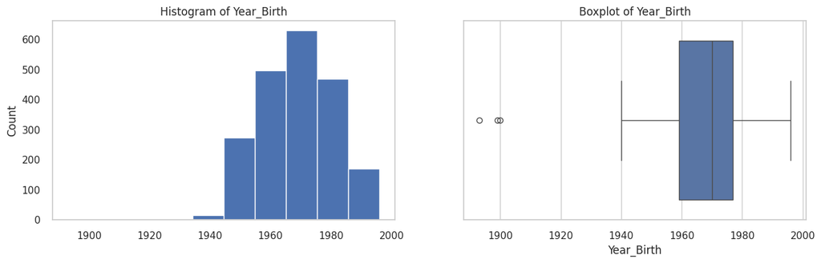

```
Observation: Year_Birth is approximately symmetric (skew = -0.38).
Possible inference: Values are fairly balanced around the center.
--------------------------------------------------------------------------------
Column: Income
Skew: 7.1
```

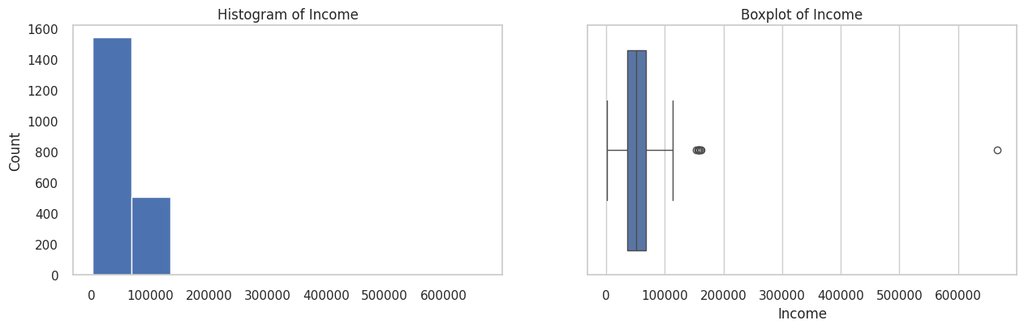

```
Observation: Income is highly **right-skewed** (positive skew = 7.1).
Possible inference: Data has a long tail to the right; a few very high values may be pulling the mean upward.
--------------------------------------------------------------------------------
Column: Kidhome
Skew: 0.62
```

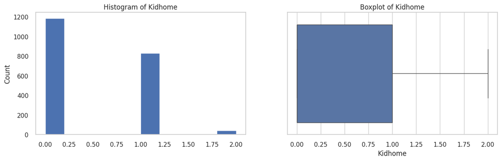

```
Observation: Kidhome is moderately **right-skewed** (positive skew = 0.62).
Possible inference: Slight concentration of lower values with some high outliers.
--------------------------------------------------------------------------------
Column: Teenhome
Skew: 0.41
```

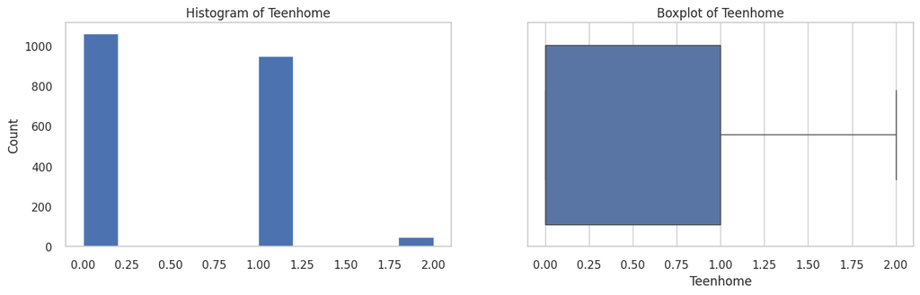

```
Observation: Teenhome is approximately symmetric (skew = 0.41).
Possible inference: Values are fairly balanced around the center.
--------------------------------------------------------------------------------
Column: Recency
Skew: 0.0
```

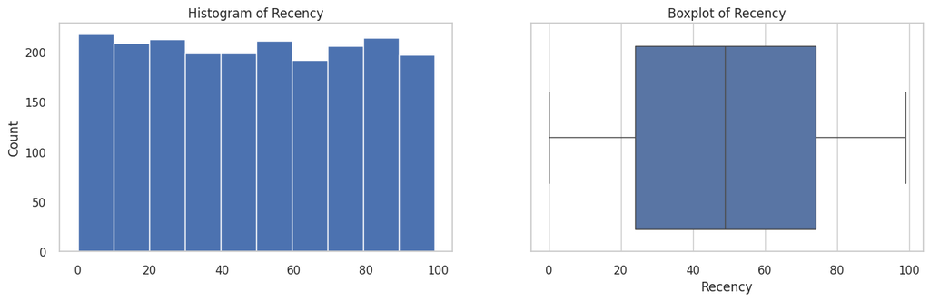

```
Observation: Recency is approximately symmetric (skew = 0.0).
Possible inference: Values are fairly balanced around the center.
--------------------------------------------------------------------------------
Column: MntWines
Skew: 1.17
```

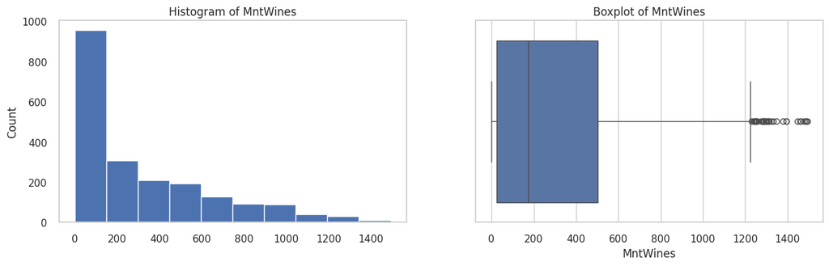

```
Observation: MntWines is highly **right-skewed** (positive skew = 1.17).
Possible inference: Data has a long tail to the right; a few very high values may be pulling the mean upward.
--------------------------------------------------------------------------------
Column: MntFruits
Skew: 2.11
```

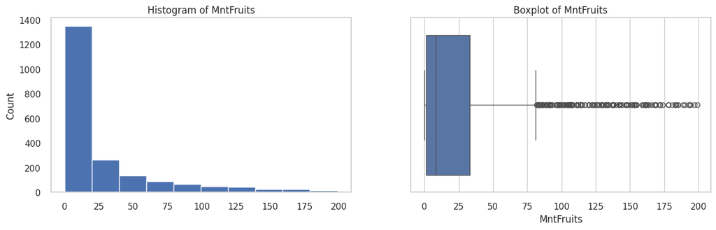

```
Observation: MntFruits is highly **right-skewed** (positive skew = 2.11).
Possible inference: Data has a long tail to the right; a few very high values may be pulling the mean upward.
--------------------------------------------------------------------------------
Column: MntMeatProducts
Skew: 2.1
```

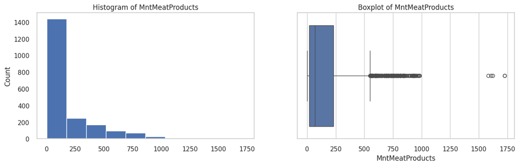

```
Observation: MntMeatProducts is highly **right-skewed** (positive skew = 2.1).
Possible inference: Data has a long tail to the right; a few very high values may be pulling the mean upward.
--------------------------------------------------------------------------------
Column: MntFishProducts
Skew: 1.93
```

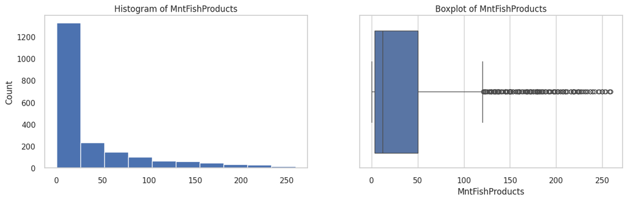

```
Observation: MntFishProducts is highly **right-skewed** (positive skew = 1.93).
Possible inference: Data has a long tail to the right; a few very high values may be pulling the mean upward.
--------------------------------------------------------------------------------
Column: MntSweetProducts
Skew: 2.15
```

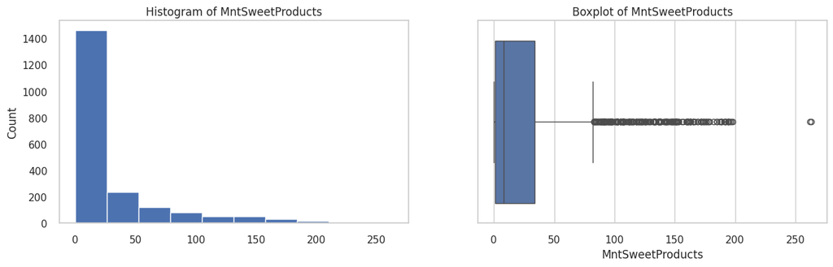

```
Observation: MntSweetProducts is highly **right-skewed** (positive skew = 2.15).
Possible inference: Data has a long tail to the right; a few very high values may be pulling the mean upward.
--------------------------------------------------------------------------------
Column: MntGoldProds
Skew: 1.91
```

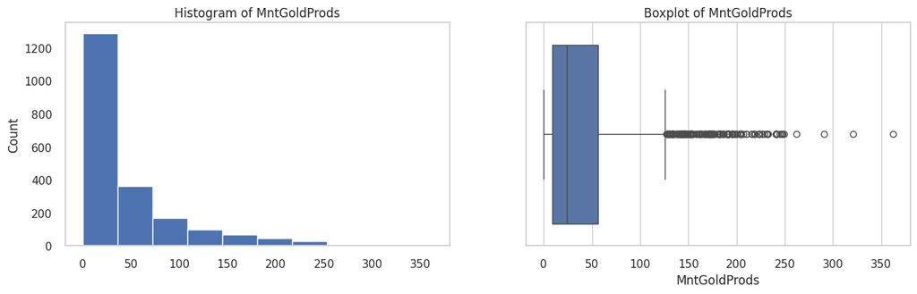

```
Observation: MntGoldProds is highly **right-skewed** (positive skew = 1.91).
Possible inference: Data has a long tail to the right; a few very high values may be pulling the mean upward.
--------------------------------------------------------------------------------
Column: NumDealsPurchases
Skew: 2.44
```

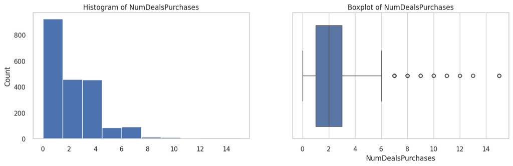

```
Observation: NumDealsPurchases is highly **right-skewed** (positive skew = 2.44).
Possible inference: Data has a long tail to the right; a few very high values may be pulling the mean upward.
--------------------------------------------------------------------------------
Column: NumWebPurchases
Skew: 1.43
```

[11 more figures not shown]

```
Observation: Response is highly **right-skewed** (positive skew = 1.94).
Possible inference: Data has a long tail to the right; a few very high values may be pulling the mean upward.
--------------------------------------------------------------------------------
```

```python
# Loop through numeric columns in df, plot, and add observations
for col in df.select_dtypes(include=['float64', 'int64']).columns:
    print(f"Column: {col}")

    # Calculate skew
    skew_value = round(df[col].skew(), 2)
    print(f"Skew: {skew_value}")

    # Create hist & boxplot
    plt.figure(figsize=(15, 4))

    # Histogram
    plt.subplot(1, 2, 1)
    df[col].hist(bins=10, grid=False)
    plt.ylabel('Count')
    plt.title(f'Histogram of {col}')

    # Boxplot
    plt.subplot(1, 2, 2)
    sns.boxplot(x=df[col])
    plt.title(f'Boxplot of {col}')

    plt.show()

    # Inference based on skewness
    if skew_value > 0.5:
        if skew_value > 1:
            print(f"Observation: {col} is highly **right-skewed** (positive skew = {skew_value}).")
            print("Possible inference: Data has a long tail to the right; a few very high values may be pulling the mean upward.")
        else:
            print(f"Observation: {col} is moderately **right-skewed** (positive skew = {skew_value}).")
            print("Possible inference: Slight concentration of lower values with some high outliers.")

    elif skew_value < -0.5:
        if skew_value < -1:
            print(f"Observation: {col} is highly **left-skewed** (negative skew = {skew_value}).")
            print("Possible inference: Data has a long tail to the left; a few very low values may be pulling the mean downward.")
        else:
            print(f"Observation: {col} is moderately **left-skewed** (negative skew = {skew_value}).")
            print("Possible inference: Slight concentration of higher values with some low outliers.")

    else:
        print(f"Observation: {col} is approximately symmetric (skew = {skew_value}).")
        print("Possible inference: Values are fairly balanced around the center.")

    print("-" * 80)
```

### Bivariate Analysis

#### **Question 6:** Perform multivariate analysis to explore the relationsips between the variables.

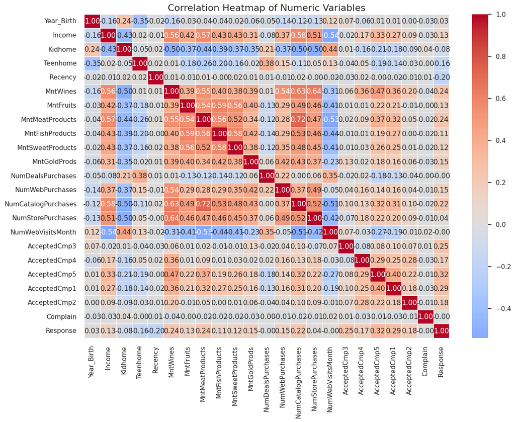

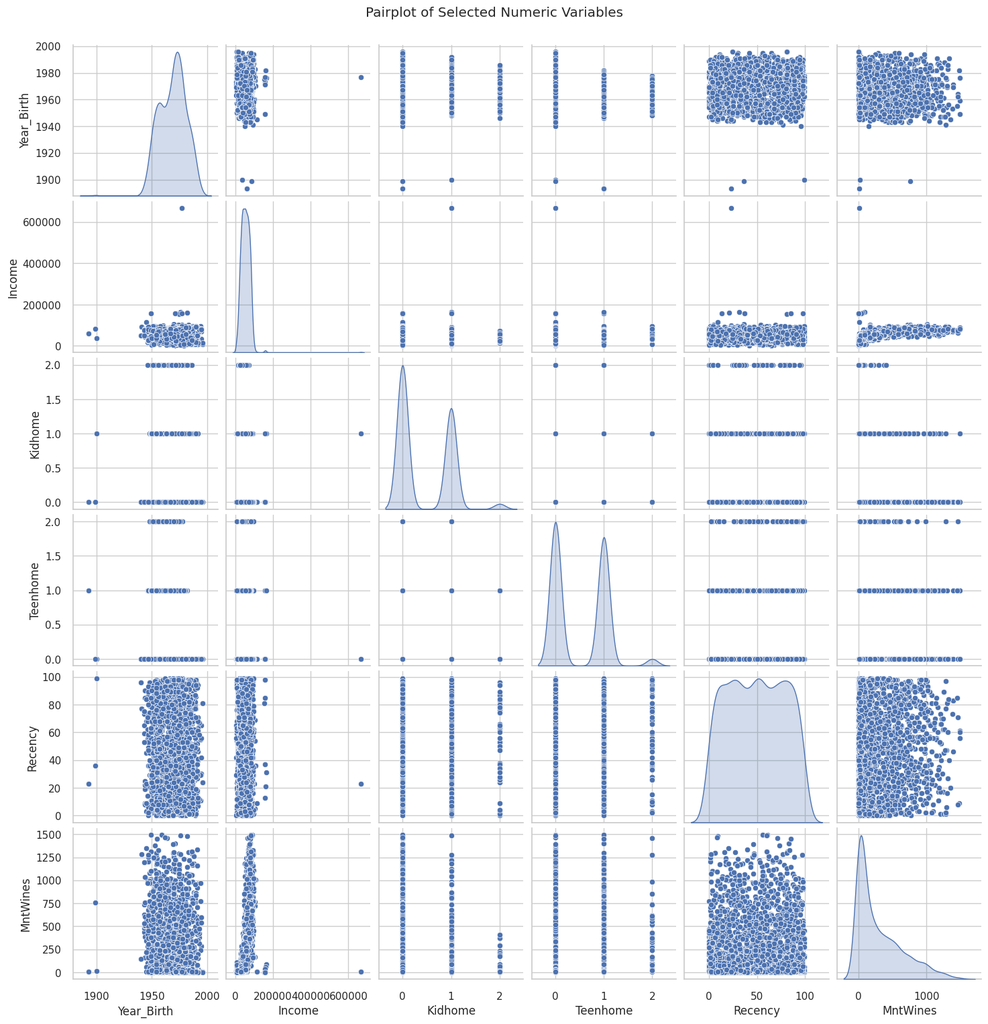

```
High correlation pairs:
 NumCatalogPurchases  MntMeatProducts        0.721638
MntMeatProducts      NumCatalogPurchases    0.721638
MntWines             NumStorePurchases      0.638452
NumStorePurchases    MntWines               0.638452
NumCatalogPurchases  MntWines               0.626678
MntWines             NumCatalogPurchases    0.626678
MntFishProducts      MntFruits              0.593156
MntFruits            MntFishProducts        0.593156
MntFishProducts      MntSweetProducts       0.579798
MntSweetProducts     MntFishProducts        0.579798
dtype: float64

Low correlation pairs:
 AcceptedCmp3       AcceptedCmp1         0.098565
AcceptedCmp1       AcceptedCmp3         0.098565
AcceptedCmp4       MntMeatProducts      0.090635
MntMeatProducts    AcceptedCmp4         0.090635
AcceptedCmp2       NumStorePurchases    0.087277
NumStorePurchases  AcceptedCmp2         0.087277
AcceptedCmp2       Income               0.085178
Income             AcceptedCmp2         0.085178
AcceptedCmp5       AcceptedCmp3         0.080363
AcceptedCmp3       AcceptedCmp5         0.080363
dtype: float64
```

```python
# Write your code here

# Select numeric columns with valid data
numeric_cols = df.select_dtypes(include=['float64', 'int64']).dropna(axis=1, how='all')

# Correlation matrix
corr_matrix = numeric_cols.corr()

# Heatmap
plt.figure(figsize=(14, 10))
sns.heatmap(corr_matrix, annot=True, fmt=".2f", cmap='coolwarm', center=0, linewidths=0.5)
plt.title("Correlation Heatmap of Numeric Variables", fontsize=16)
plt.show()

# Pairplot (pick first 6 numeric columns to keep it readable)
sns.pairplot(numeric_cols.iloc[:, :6], diag_kind='kde')
plt.suptitle("Pairplot of Selected Numeric Variables", y=1.02)
plt.show()

# Flatten correlation matrix
corr_pairs = corr_matrix.unstack().sort_values(ascending=False)

# Filter out self-correlations
corr_pairs = corr_pairs[corr_pairs < 1]

# Top correlations (absolute > 0.5)
high_corr_pairs = corr_pairs[abs(corr_pairs) > 0.5]
print("High correlation pairs:\n", high_corr_pairs.head(10))

# Bottom correlations (absolute < 0.1)
low_corr_pairs = corr_pairs[abs(corr_pairs) < 0.1]
print("\nLow correlation pairs:\n", low_corr_pairs.head(10))
```

##### **Observations:**

**High correlation pairs**

- NumCatalogPurchases & MntMeatProducts (0.72): Customers who buy more via catalogs tend to spend significantly on meat products.
- MntWines & NumStorePurchases (0.64): Higher wine spending is linked to more frequent store visits, suggesting wines are more often purchased in-store.
- NumCatalogPurchases & MntWines (0.63): Catalog buyers tend to spend more on wines, indicating catalogs are effective for promoting premium wines.
- MntFishProducts & MntFruits (0.59): Spending on fish and fruits often occurs together, showing preference for healthy fresh food combinations.
- MntFishProducts & MntSweetProducts (0.58): Customers buying fish also tend to purchase sweet products, indicating a diverse grocery basket.

**Low correlation pairs**

- AcceptedCmp3 & AcceptedCmp1 (0.10): Minimal relationship between acceptance of campaign 3 and campaign 1, suggesting independent campaign responses.
- AcceptedCmp4 & MntMeatProducts (0.09): Very weak link between accepting campaign 4 and spending on meat products, showing campaign 4 likely targeted other categories.
- AcceptedCmp2 & NumStorePurchases (0.09): Little connection between accepting campaign 2 and frequency of store purchases.
- AcceptedCmp2 & Income (0.09): No meaningful association between acceptance of campaign 2 and customer income levels.
- AcceptedCmp5 & AcceptedCmp3 (0.08): Weak correlation between responses to campaigns 5 and 3, indicating independent decision-making across campaigns.

## **K-means Clustering**

#### **Question 7** : Select the appropriate number of clusters using the elbow Plot. What do you think is the appropriate number of clusters?

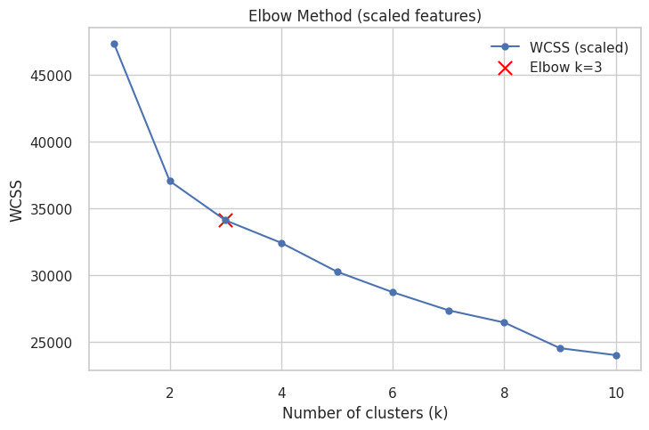

```
Best elbow k (distance-to-line heuristic): 3
```

```python
# Write your code here


# 1) Select numeric columns
df_numeric = df.select_dtypes(include=['number']).copy()

# 2) Scale them (IMPORTANT for K-Means)
scaler = StandardScaler()
X = scaler.fit_transform(df_numeric)   # <-- use X from here on

# 3) Elbow method on scaled data
K = range(1, 11)
wcss = []
for k in K:
    km = KMeans(n_clusters=k, random_state=42, n_init='auto')
    km.fit(X)                          # <-- use X (scaled), not df_numeric
    wcss.append(km.inertia_)

# 4) Distance-to-line heuristic to pick elbow k
ks = np.array(list(K), dtype=float)
w = np.array(wcss, dtype=float)
p1 = np.array([ks[0], w[0]])
p2 = np.array([ks[-1], w[-1]])
line_vec = p2 - p1
dist = np.abs(np.cross(line_vec, np.column_stack([ks, w]) - p1)) / np.linalg.norm(line_vec)
elbow_k = int(ks[np.argmax(dist)])

# 5) Plot
plt.figure(figsize=(8, 5))
plt.plot(ks, w, 'bo-', label='WCSS (scaled)')
plt.scatter([elbow_k], [wcss[elbow_k-1]], s=120, marker='x', color='red', label=f'Elbow k={elbow_k}')
plt.xlabel('Number of clusters (k)')
plt.ylabel('WCSS')
plt.title('Elbow Method (scaled features)')
plt.legend()
plt.show()

print(f"Best elbow k (distance-to-line heuristic): {elbow_k}")
```

##### **Observations:**

Using the elbow method on the scaled dataset, the Within-Cluster Sum of Squares (WCSS) shows a sharp drop from k=1 to k=3, after which the rate of decrease slows noticeably. This indicates that most of the variance is explained by the first three clusters, and adding more clusters beyond this point results in diminishing returns. The distance-to-line heuristic clearly identifies k=3 as the elbow point, suggesting that the dataset naturally forms three meaningful groupings.

**Key Takeaway:** k=3 provides a balance between simplicity and granularity, capturing the main structure of the data while avoiding overfitting with too many clusters.

#### **Question 8** : finalize appropriate number of clusters by checking the silhoutte score as well. Is the answer different from the elbow plot?

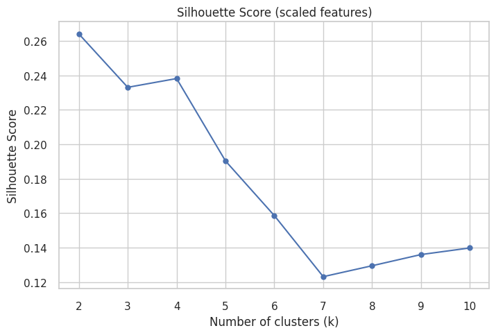

```
Silhouette Scores (Highest to Lowest):
k = 2: 0.2642 <--- Best k
k = 4: 0.2382
k = 3: 0.2331
k = 5: 0.1904
k = 6: 0.1586
k = 10: 0.1398
k = 9: 0.1360
k = 8: 0.1295
k = 7: 0.1231
```

```python
# Write your code here


# --- Scale numeric features ---
scaler = StandardScaler()
df_scaled = scaler.fit_transform(df_numeric)

# --- Silhouette scores ---
silhouette_scores = {}
for k in range(2, 11):
    kmeans = KMeans(n_clusters=k, random_state=42)
    labels = kmeans.fit_predict(df_scaled)  # use scaled data
    silhouette_scores[k] = silhouette_score(df_scaled, labels)

# --- Plot ---
plt.figure(figsize=(8, 5))
plt.plot(list(silhouette_scores.keys()), list(silhouette_scores.values()), 'bo-')
plt.xlabel('Number of clusters (k)')
plt.ylabel('Silhouette Score')
plt.title('Silhouette Score (scaled features)')
plt.show()

# --- Print sorted scores ---
print("Silhouette Scores (Highest to Lowest):")
best_k, best_score = max(silhouette_scores.items(), key=lambda x: x[1])
for k, score in sorted(silhouette_scores.items(), key=lambda x: x[1], reverse=True):
    marker = " <--- Best k" if k == best_k else ""
    print(f"k = {k}: {score:.4f}{marker}")
```

##### **Observations:**

**Key Takeaway:** k=2 results in the most distinct and well-separated clusters, ideal when prioritizing clear group boundaries over fine-grained segmentation.

#### **Question 9**: Do a final fit with the appropriate number of clusters. How much total time does it take for the model to fit the data?

```python
# Write your code here


# Select only numeric columns
df_numeric = df.select_dtypes(include=['number'])

# Set the final number of clusters based on earlier analysis (e.g., k=2 or k=4)
final_k = 3  # change this if you decided on another k

# Measure fit time
start_time = time.time()
kmeans_final = KMeans(n_clusters=final_k, random_state=42)
kmeans_final.fit(df_numeric)
end_time = time.time()

# Total time taken
fit_time = end_time - start_time

print(f"Final model fitted with k={final_k} in {fit_time:.4f} seconds.")
```

```
Final model fitted with k=3 in 0.0068 seconds.
```

```python
# 1) Use numeric features
df_numeric = df.select_dtypes(include='number')

# 2) Set k from your Elbow plot (replace 4 with your chosen k)
best_k = 2

# 3) Fit and time it
start = time.time()
kmeans = KMeans(n_clusters=best_k, random_state=42)
kmeans.fit(df_numeric)
fit_time = time.time() - start

print(f"Final fit with k={best_k} completed in {fit_time:.4f} seconds.")
```

```
Final fit with k=2 completed in 0.0039 seconds.
```

##### **Observations:**

**Key Takeaway:** When computation time is insignificant, prioritizing clustering quality over speed ensures more meaningful and interpretable segmentation results.